# RNA-seq analysis.

RNA-seq analysis for Greenberg group at Longwood.

Contact Lorena Pantano (lpantano@hsph.harvard.edu) for additional details.

The most recent update of this html document occurred: Wed Oct 5 15:11:50 2016

The sections below provide code to reproduce the included results and plots.

```r
library(ggplot2)
library(reshape)
library(gplots)
library(CHBUtils)
library(DESeq2)
library(logging)
library(gridExtra)
library(clusterProfiler)
library(DOSE)
library(org.Mm.eg.db)
library(cluster)
library(dplyr)
library(DEGreport)

# library(DT)

basicConfig()

comp_keep = c("ctl_over_time.tsv")
comp = list()
for (name in comp_keep){
    comp[[name]] = readr::read_tsv(file.path(path_results, name))
}
metadata_full = read.csv(file.path(path_results, "..", "2016-02-29_ldr_model","project-summary.csv"), row.names="Name")
```

Used genes with peaks at P4/P10/P16:

- P4: groups 9
- P10: groups 8,11
- P16: groups 3,4

To create the groups we used all de-regulated genes over time in Ctl, and then clustered together to show the patterns. The patterns that made a peak at the desired times were selected as input for the GO analysis.

```r
tpm = read.csv(file.path(path_results, "counts_tpm_with_fc.csv"),
                 row.names=1)

keep = comp[[1]]$padj<0.01 & !is.na(comp[[1]]$padj) & abs(comp[[1]]$log2FoldChange) > 2
samples = (grepl("ctl", names(tpm))) & !grepl("log2", names(tpm)) & !grepl("padj", names(tpm))
# samples = !grepl("log2", names(tpm)) & !grepl("padj", names(tpm)) & !(grepl("symbol", names(tpm)))
ma=as.matrix(tpm[as.character(comp[[1]]$id[keep]),samples])
ma[is.na(ma)] = 0
metadata = metadata_full[colnames(ma),]
metadata$type=metadata$group
metadata$group=droplevels(as.factor(paste0(metadata$type, metadata$time)))
pattern = degPatterns(ma, metadata = metadata, col = "type", time = "time", summarize = "group", minc = 15)
```

```
Working with  2068  genes
```

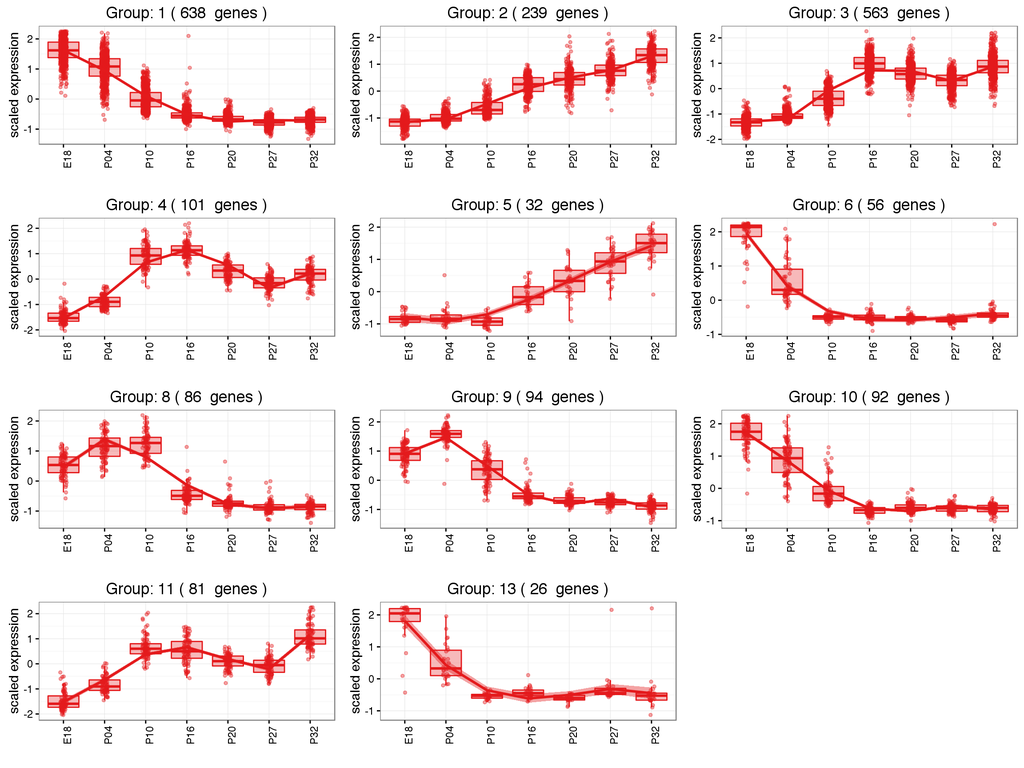

```r
genes_keep = pattern$df$genes
comp_run = list()
for (c in unique(pattern$df$cluster)){
    comp_run[[paste0("C",c)]] = as.character(pattern$df$genes[pattern$df$cluster==c])
}
# tpm = tpm[!is.na(tpm[,1]),]
save_file(tpm[genes_keep,],"P4P10P16_counts_tpm_with_fc.csv", path_results)
```

```r
asd_terms = read.csv("~/orch/scratch/greenberg_rnaseq/lgn2/final/all-terms.csv", row.names=1)
```

# GO enrichment using DE genes

## Standard GO analysis

```r
go_res = data.frame()
for (name in names(comp_run)){
    cat("### Go enrichment for cluster:", name, "\n\n")
    keep = as.character(comp_run[[name]])
    cat("Working with ", length(keep), " genes\n\n")
    ego <- enrichGO(keep, org.Mm.eg.db, keytype = "ENSEMBL", ont = "BP", universe = as.character(comp[[1]]$id))
    ego <- simplify(ego)
    cat("\n\n")
    print(kable(ego@result[,1:7]))
    cat("\n\n")
    if (nrow(ego@result)==0) next;
    symbol = sapply(ego@result$geneID, function(x){
        paste(convertIDs(unique(unlist(strsplit(x,"/"))),
                         "ENSEMBL", "SYMBOL",
                         org.Mm.eg.db, "useFirst"), collapse = " ")
    })
    dt = ego@result
    dt$symbol = symbol
    dt$comparision = name
    go_res = rbind(go_res, dt)
}
```

### Go enrichment for cluster: C1

Working with 638 genes

|  | ID | Description | GeneRatio | BgRatio | pvalue | p.adjust | qvalue |
| --- | --- | --- | --- | --- | --- | --- | --- |
| GO:0098742 | GO:0098742 | cell-cell adhesion via plasma-membrane adhesion molecules | 17/508 | 133/17641 | 3.00e-07 | 0.0008667 | 0.0008587 |
| GO:0035082 | GO:0035082 | axoneme assembly | 9/508 | 45/17641 | 4.50e-06 | 0.0056083 | 0.0055561 |
| GO:0007411 | GO:0007411 | axon guidance | 18/508 | 194/17641 | 1.34e-05 | 0.0089255 | 0.0088424 |
| GO:0097485 | GO:0097485 | neuron projection guidance | 18/508 | 195/17641 | 1.43e-05 | 0.0089255 | 0.0088424 |

### Go enrichment for cluster: C2

Working with 239 genes

|  | ID | Description | GeneRatio | BgRatio | pvalue | p.adjust | qvalue |
| --- | --- | --- | --- | --- | --- | --- | --- |
| GO:0031032 | GO:0031032 | actomyosin structure organization | 9/190 | 146/17641 | 2.93e-05 | 0.0282208 | 0.0265307 |
| GO:0042552 | GO:0042552 | myelination | 8/190 | 120/17641 | 4.69e-05 | 0.0282208 | 0.0265307 |
| GO:0007272 | GO:0007272 | ensheathment of neurons | 8/190 | 122/17641 | 5.28e-05 | 0.0282208 | 0.0265307 |
| GO:0008366 | GO:0008366 | axon ensheathment | 8/190 | 122/17641 | 5.28e-05 | 0.0282208 | 0.0265307 |
| GO:0006821 | GO:0006821 | chloride transport | 7/190 | 93/17641 | 6.53e-05 | 0.0282208 | 0.0265307 |

### Go enrichment for cluster: C3

Working with 563 genes

|  | ID | Description | GeneRatio | BgRatio | pvalue | p.adjust | qvalue |
| --- | --- | --- | --- | --- | --- | --- | --- |
| GO:0098662 | GO:0098662 | inorganic cation transmembrane transport | 48/490 | 494/17641 | 0.0000000 | 0.0000000 | 0.0000000 |
| GO:0071805 | GO:0071805 | potassium ion transmembrane transport | 26/490 | 149/17641 | 0.0000000 | 0.0000000 | 0.0000000 |
| GO:0071804 | GO:0071804 | cellular potassium ion transport | 26/490 | 150/17641 | 0.0000000 | 0.0000000 | 0.0000000 |
| GO:0007272 | GO:0007272 | ensheathment of neurons | 19/490 | 122/17641 | 0.0000000 | 0.0000004 | 0.0000004 |
| GO:0008366 | GO:0008366 | axon ensheathment | 19/490 | 122/17641 | 0.0000000 | 0.0000004 | 0.0000004 |
| GO:0007268 | GO:0007268 | synaptic transmission | 37/490 | 489/17641 | 0.0000000 | 0.0000101 | 0.0000090 |
| GO:0099536 | GO:0099536 | synaptic signaling | 37/490 | 489/17641 | 0.0000000 | 0.0000101 | 0.0000090 |
| GO:0099537 | GO:0099537 | trans-synaptic signaling | 37/490 | 489/17641 | 0.0000000 | 0.0000101 | 0.0000090 |
| GO:1901615 | GO:1901615 | organic hydroxy compound metabolic process | 31/490 | 421/17641 | 0.0000009 | 0.0001548 | 0.0001373 |
| GO:0055065 | GO:0055065 | metal ion homeostasis | 32/490 | 494/17641 | 0.0000087 | 0.0012031 | 0.0010672 |
| GO:0044057 | GO:0044057 | regulation of system process | 30/490 | 448/17641 | 0.0000088 | 0.0012031 | 0.0010672 |
| GO:0010975 | GO:0010975 | regulation of neuron projection development | 30/490 | 459/17641 | 0.0000140 | 0.0016662 | 0.0014780 |
| GO:0007009 | GO:0007009 | plasma membrane organization | 21/490 | 271/17641 | 0.0000241 | 0.0025255 | 0.0022404 |
| GO:0071248 | GO:0071248 | cellular response to metal ion | 11/490 | 87/17641 | 0.0000283 | 0.0028748 | 0.0025503 |
| GO:0044708 | GO:0044708 | single-organism behavior | 28/490 | 447/17641 | 0.0000574 | 0.0052389 | 0.0046474 |
| GO:0042391 | GO:0042391 | regulation of membrane potential | 24/490 | 356/17641 | 0.0000624 | 0.0055524 | 0.0049255 |
| GO:0051937 | GO:0051937 | catecholamine transport | 9/490 | 65/17641 | 0.0000734 | 0.0062030 | 0.0055027 |
| GO:0050432 | GO:0050432 | catecholamine secretion | 8/490 | 51/17641 | 0.0000746 | 0.0062030 | 0.0055027 |
| GO:0043092 | GO:0043092 | L-amino acid import | 5/490 | 17/17641 | 0.0000760 | 0.0062030 | 0.0055027 |
| GO:0001505 | GO:0001505 | regulation of neurotransmitter levels | 14/490 | 152/17641 | 0.0000888 | 0.0068722 | 0.0060963 |
| GO:0007266 | GO:0007266 | Rho protein signal transduction | 13/490 | 141/17641 | 0.0001557 | 0.0099008 | 0.0087829 |
| GO:0060350 | GO:0060350 | endochondral bone morphogenesis | 7/490 | 46/17641 | 0.0002559 | 0.0146977 | 0.0130383 |
| GO:0006836 | GO:0006836 | neurotransmitter transport | 13/490 | 149/17641 | 0.0002694 | 0.0149919 | 0.0132993 |
| GO:1901890 | GO:1901890 | positive regulation of cell junction assembly | 5/490 | 23/17641 | 0.0003601 | 0.0185856 | 0.0164872 |
| GO:0061448 | GO:0061448 | connective tissue development | 16/490 | 220/17641 | 0.0004485 | 0.0215809 | 0.0191443 |
| GO:0050954 | GO:0050954 | sensory perception of mechanical stimulus | 13/490 | 158/17641 | 0.0004758 | 0.0224399 | 0.0199064 |
| GO:0070997 | GO:0070997 | neuron death | 20/490 | 324/17641 | 0.0007717 | 0.0312291 | 0.0277032 |
| GO:0035637 | GO:0035637 | multicellular organismal signaling | 10/490 | 109/17641 | 0.0009120 | 0.0353015 | 0.0313158 |
| GO:0042982 | GO:0042982 | amyloid precursor protein metabolic process | 5/490 | 28/17641 | 0.0009381 | 0.0359219 | 0.0318662 |
| GO:0032922 | GO:0032922 | circadian regulation of gene expression | 7/490 | 58/17641 | 0.0010798 | 0.0396417 | 0.0351660 |
| GO:0050905 | GO:0050905 | neuromuscular process | 10/490 | 114/17641 | 0.0012878 | 0.0447951 | 0.0397376 |
| GO:0006979 | GO:0006979 | response to oxidative stress | 19/490 | 315/17641 | 0.0013561 | 0.0447951 | 0.0397376 |
| GO:0001525 | GO:0001525 | angiogenesis | 23/490 | 415/17641 | 0.0013882 | 0.0447951 | 0.0397376 |
| GO:0043410 | GO:0043410 | positive regulation of MAPK cascade | 23/490 | 415/17641 | 0.0013882 | 0.0447951 | 0.0397376 |
| GO:0007422 | GO:0007422 | peripheral nervous system development | 7/490 | 61/17641 | 0.0014590 | 0.0463154 | 0.0410861 |
| GO:0007187 | GO:0007187 | G-protein coupled receptor signaling pathway, coupled to cyclic nucleotide second messenger | 11/490 | 137/17641 | 0.0015488 | 0.0475470 | 0.0421787 |

### Go enrichment for cluster: C4

Working with 101 genes

|  | ID | Description | GeneRatio | BgRatio | pvalue | p.adjust | qvalue |
| --- | --- | --- | --- | --- | --- | --- | --- |
| GO:0055067 | GO:0055067 | monovalent inorganic cation homeostasis | 8/90 | 123/17641 | 2.00e-07 | 0.0003644 | 0.0003283 |
| GO:0019755 | GO:0019755 | one-carbon compound transport | 3/90 | 14/17641 | 4.49e-05 | 0.0286524 | 0.0258140 |
| GO:0015711 | GO:0015711 | organic anion transport | 9/90 | 341/17641 | 6.05e-05 | 0.0286524 | 0.0258140 |
| GO:0048678 | GO:0048678 | response to axon injury | 4/90 | 43/17641 | 6.71e-05 | 0.0286524 | 0.0258140 |

### Go enrichment for cluster: C5

Working with 32 genes

ID Description GeneRatio BgRatio pvalue p.adjust qvalue — ———— ———- ——– ——- ——— ——-

### Go enrichment for cluster: C6

Working with 56 genes

|  | ID | Description | GeneRatio | BgRatio | pvalue | p.adjust | qvalue |
| --- | --- | --- | --- | --- | --- | --- | --- |
| GO:0007018 | GO:0007018 | microtubule-based movement | 8/46 | 202/17641 | 0.00e+00 | 0.0000366 | 0.0000319 |
| GO:0007389 | GO:0007389 | pattern specification process | 8/46 | 432/17641 | 1.40e-05 | 0.0022121 | 0.0019281 |
| GO:0048663 | GO:0048663 | neuron fate commitment | 4/46 | 72/17641 | 3.66e-05 | 0.0041314 | 0.0036011 |

### Go enrichment for cluster: C8

Working with 86 genes

ID Description GeneRatio BgRatio pvalue p.adjust qvalue — ———— ———- ——– ——- ——— ——-

### Go enrichment for cluster: C9

Working with 94 genes

|  | ID | Description | GeneRatio | BgRatio | pvalue | p.adjust | qvalue |
| --- | --- | --- | --- | --- | --- | --- | --- |
| GO:0006323 | GO:0006323 | DNA packaging | 7/77 | 142/17641 | 2.8e-06 | 0.0038097 | 0.0035086 |

### Go enrichment for cluster: C10

Working with 92 genes

ID Description GeneRatio BgRatio pvalue p.adjust qvalue — ———— ———- ——– ——- ——— ——-

### Go enrichment for cluster: C11

Working with 81 genes

ID Description GeneRatio BgRatio pvalue p.adjust qvalue — ———— ———- ——– ——- ——— ——-

### Go enrichment for cluster: C13

Working with 26 genes

ID Description GeneRatio BgRatio pvalue p.adjust qvalue — ———— ———- ——– ——- ——— ——-

```r
write.csv(go_res, file.path(path_results, paste0("P4P10P16", "_time-go_res_standard.csv")))
```

## Custom GO analysis

```r
go_res = data.frame()
for (name in names(comp_run)){
    cat("### Go enrichment for cluster:", name, "\n\n")
    keep = as.character(comp_run[[name]])
    cat("Working with ", length(keep), " genes\n\n")
    go_fake = rbind(asd_terms, data.frame(go="GO_control", genes=comp[[1]]$id))

    go_name = data.frame(go=c(as.character(unique(asd_terms$go)),
                              "GO_everything.else"),
                         name=c(as.character(unique(asd_terms$go)), "control"))

    if (length(keep) == 0){
        cat("\n\nNo DE genes in this comparison\n\n");next}
    write.csv(tpm[keep,], file.path(path_results, paste0(name, "used4go-tpm.csv")))
    cp = enricher( keep, universe = as.character(comp[[1]]$id),
                   pvalueCutoff = 1, qvalueCutoff = 1,
                   TERM2GENE = go_fake, maxGSSize = 8000,
                   TERM2NAME = go_name, minGSSize = 2)
    cat("\n")
    if (!("result" %in% slotNames(cp))){
        cat("\n\nNo Genes in any terms in this comparison\n\n");next}

    print(kable(cp@result[,1:6]))
    # cat("\n\ngenes in GO term\n\n")
    symbol = sapply(cp@result$geneID, function(x){
        paste(convertIDs(unique(unlist(strsplit(x,"/"))),
                         "ENSEMBL", "SYMBOL",
                         org.Mm.eg.db, "useFirst"), collapse = " ")
    })
    cat("\n\n")
    dt = cp@result
    dt$symbol = symbol
    dt$comparision = name
    go_res = rbind(go_res, dt)
}
```

### Go enrichment for cluster: C1

Working with 638 genes

|  | ID | Description | GeneRatio | BgRatio | pvalue | p.adjust |
| --- | --- | --- | --- | --- | --- | --- |
| transmembrane | transmembrane | transmembrane | 144/638 | 4857/28597 | 0.0001473 | 0.0017670 |
| protein_class_secreted.txt | protein_class_secreted.txt | protein_class_secreted.txt | 56/638 | 1678/28597 | 0.0018083 | 0.0108497 |
| ASD_m16.txt | ASD_m16.txt | ASD_m16.txt | 12/638 | 336/28597 | 0.0755105 | 0.2602977 |
| signaling-terms.txt | signaling-terms.txt | signaling-terms.txt | 4/638 | 75/28597 | 0.0867659 | 0.2602977 |
| ASD_SFARI 2012_CV.txt | ASD_SFARI 2012_CV.txt | ASD_SFARI 2012_CV.txt | 6/638 | 183/28597 | 0.2257799 | 0.5418717 |
| ASD_SFARI 2012.txt | ASD_SFARI 2012.txt | ASD_SFARI 2012.txt | 9/638 | 320/28597 | 0.2872592 | 0.5745185 |
| immune2-terms.txt | immune2-terms.txt | immune2-terms.txt | 12/638 | 525/28597 | 0.5068867 | 0.8689486 |
| regulation-terms.txt | regulation-terms.txt | regulation-terms.txt | 27/638 | 1317/28597 | 0.7023074 | 0.8739870 |
| immune-terms.txt | immune-terms.txt | immune-terms.txt | 23/638 | 1145/28597 | 0.7268373 | 0.8739870 |
| immune-microglia-terms.txt | immune-microglia-terms.txt | immune-microglia-terms.txt | 23/638 | 1146/28597 | 0.7283225 | 0.8739870 |
| ASD_Pinto.txt | ASD_Pinto.txt | ASD_Pinto.txt | 1/638 | 122/28597 | 0.9366165 | 0.9744626 |
| ASD_m12.txt | ASD_m12.txt | ASD_m12.txt | 4/638 | 387/28597 | 0.9744626 | 0.9744626 |

### Go enrichment for cluster: C2

Working with 239 genes

|  | ID | Description | GeneRatio | BgRatio | pvalue | p.adjust |
| --- | --- | --- | --- | --- | --- | --- |
| transmembrane | transmembrane | transmembrane | 63/239 | 4857/28597 | 0.0001656 | 0.0019877 |
| protein_class_secreted.txt | protein_class_secreted.txt | protein_class_secreted.txt | 25/239 | 1678/28597 | 0.0037677 | 0.0226064 |
| immune-terms.txt | immune-terms.txt | immune-terms.txt | 18/239 | 1145/28597 | 0.0079513 | 0.0240571 |
| immune-microglia-terms.txt | immune-microglia-terms.txt | immune-microglia-terms.txt | 18/239 | 1146/28597 | 0.0080190 | 0.0240571 |
| immune2-terms.txt | immune2-terms.txt | immune2-terms.txt | 10/239 | 525/28597 | 0.0133850 | 0.0321239 |
| ASD_SFARI 2012_CV.txt | ASD_SFARI 2012_CV.txt | ASD_SFARI 2012_CV.txt | 4/239 | 183/28597 | 0.0679810 | 0.1359619 |
| signaling-terms.txt | signaling-terms.txt | signaling-terms.txt | 2/239 | 75/28597 | 0.1301104 | 0.2230464 |
| ASD_SFARI 2012.txt | ASD_SFARI 2012.txt | ASD_SFARI 2012.txt | 4/239 | 320/28597 | 0.2795529 | 0.4193294 |
| ASD_m16.txt | ASD_m16.txt | ASD_m16.txt | 3/239 | 336/28597 | 0.5344172 | 0.6999187 |
| ASD_m12.txt | ASD_m12.txt | ASD_m12.txt | 3/239 | 387/28597 | 0.6300159 | 0.6999187 |
| ASD_Pinto.txt | ASD_Pinto.txt | ASD_Pinto.txt | 1/239 | 122/28597 | 0.6415921 | 0.6999187 |
| regulation-terms.txt | regulation-terms.txt | regulation-terms.txt | 8/239 | 1317/28597 | 0.8643511 | 0.8643511 |

### Go enrichment for cluster: C3

Working with 563 genes

|  | ID | Description | GeneRatio | BgRatio | pvalue | p.adjust |
| --- | --- | --- | --- | --- | --- | --- |
| transmembrane | transmembrane | transmembrane | 200/563 | 4857/28597 | 0.0000000 | 0.0000000 |
| ASD_m12.txt | ASD_m12.txt | ASD_m12.txt | 23/563 | 387/28597 | 0.0000032 | 0.0000206 |
| protein_class_secreted.txt | protein_class_secreted.txt | protein_class_secreted.txt | 58/563 | 1678/28597 | 0.0000240 | 0.0001041 |
| microglia-terms.txt | microglia-terms.txt | microglia-terms.txt | 3/563 | 15/28597 | 0.0028947 | 0.0091658 |
| ASD_SFARI 2012_CV.txt | ASD_SFARI 2012_CV.txt | ASD_SFARI 2012_CV.txt | 10/563 | 183/28597 | 0.0035253 | 0.0091658 |
| ASD_SFARI 2012.txt | ASD_SFARI 2012.txt | ASD_SFARI 2012.txt | 14/563 | 320/28597 | 0.0047634 | 0.0103208 |
| immune2-terms.txt | immune2-terms.txt | immune2-terms.txt | 18/563 | 525/28597 | 0.0171119 | 0.0317792 |
| immune-microglia-terms.txt | immune-microglia-terms.txt | immune-microglia-terms.txt | 31/563 | 1146/28597 | 0.0474560 | 0.0771160 |
| signaling-terms.txt | signaling-terms.txt | signaling-terms.txt | 4/563 | 75/28597 | 0.0606277 | 0.0875733 |
| immune-terms.txt | immune-terms.txt | immune-terms.txt | 30/563 | 1145/28597 | 0.0699282 | 0.0909067 |
| ASD_m16.txt | ASD_m16.txt | ASD_m16.txt | 10/563 | 336/28597 | 0.1292949 | 0.1528031 |
| ASD_Pinto.txt | ASD_Pinto.txt | ASD_Pinto.txt | 4/563 | 122/28597 | 0.2201296 | 0.2384738 |
| regulation-terms.txt | regulation-terms.txt | regulation-terms.txt | 24/563 | 1317/28597 | 0.6809608 | 0.6809608 |

### Go enrichment for cluster: C4

Working with 101 genes

|  | ID | Description | GeneRatio | BgRatio | pvalue | p.adjust |
| --- | --- | --- | --- | --- | --- | --- |
| transmembrane | transmembrane | transmembrane | 39/101 | 4857/28597 | 0.0000002 | 0.0000020 |
| ASD_m16.txt | ASD_m16.txt | ASD_m16.txt | 7/101 | 336/28597 | 0.0001942 | 0.0010680 |
| protein_class_secreted.txt | protein_class_secreted.txt | protein_class_secreted.txt | 14/101 | 1678/28597 | 0.0022999 | 0.0084330 |
| ASD_m12.txt | ASD_m12.txt | ASD_m12.txt | 5/101 | 387/28597 | 0.0121588 | 0.0334366 |
| immune-terms.txt | immune-terms.txt | immune-terms.txt | 7/101 | 1145/28597 | 0.1106458 | 0.2035340 |
| immune-microglia-terms.txt | immune-microglia-terms.txt | immune-microglia-terms.txt | 7/101 | 1146/28597 | 0.1110185 | 0.2035340 |
| ASD_SFARI 2012_CV.txt | ASD_SFARI 2012_CV.txt | ASD_SFARI 2012_CV.txt | 2/101 | 183/28597 | 0.1367757 | 0.2149332 |
| signaling-terms.txt | signaling-terms.txt | signaling-terms.txt | 1/101 | 75/28597 | 0.2333319 | 0.3208314 |
| ASD_SFARI 2012.txt | ASD_SFARI 2012.txt | ASD_SFARI 2012.txt | 2/101 | 320/28597 | 0.3123497 | 0.3817607 |
| immune2-terms.txt | immune2-terms.txt | immune2-terms.txt | 2/101 | 525/28597 | 0.5558307 | 0.6114137 |
| regulation-terms.txt | regulation-terms.txt | regulation-terms.txt | 3/101 | 1317/28597 | 0.8496220 | 0.8496220 |

### Go enrichment for cluster: C5

Working with 32 genes

|  | ID | Description | GeneRatio | BgRatio | pvalue | p.adjust |
| --- | --- | --- | --- | --- | --- | --- |
| transmembrane | transmembrane | transmembrane | 9/32 | 4857/28597 | 0.0802270 | 0.2310844 |
| protein_class_secreted.txt | protein_class_secreted.txt | protein_class_secreted.txt | 4/32 | 1678/28597 | 0.1155422 | 0.2310844 |
| immune-terms.txt | immune-terms.txt | immune-terms.txt | 1/32 | 1145/28597 | 0.7297299 | 0.7300449 |
| immune-microglia-terms.txt | immune-microglia-terms.txt | immune-microglia-terms.txt | 1/32 | 1146/28597 | 0.7300449 | 0.7300449 |

### Go enrichment for cluster: C6

Working with 56 genes

|  | ID | Description | GeneRatio | BgRatio | pvalue | p.adjust |
| --- | --- | --- | --- | --- | --- | --- |
| protein_class_secreted.txt | protein_class_secreted.txt | protein_class_secreted.txt | 6/56 | 1678/28597 | 0.1089654 | 0.6718088 |
| immune-terms.txt | immune-terms.txt | immune-terms.txt | 3/56 | 1145/28597 | 0.3899321 | 0.6718088 |
| immune-microglia-terms.txt | immune-microglia-terms.txt | immune-microglia-terms.txt | 3/56 | 1146/28597 | 0.3904671 | 0.6718088 |
| ASD_SFARI 2012.txt | ASD_SFARI 2012.txt | ASD_SFARI 2012.txt | 1/56 | 320/28597 | 0.4678244 | 0.6718088 |
| regulation-terms.txt | regulation-terms.txt | regulation-terms.txt | 3/56 | 1317/28597 | 0.4798634 | 0.6718088 |
| immune2-terms.txt | immune2-terms.txt | immune2-terms.txt | 1/56 | 525/28597 | 0.6460652 | 0.7537427 |
| transmembrane | transmembrane | transmembrane | 6/56 | 4857/28597 | 0.9310416 | 0.9310416 |

### Go enrichment for cluster: C8

Working with 86 genes

|  | ID | Description | GeneRatio | BgRatio | pvalue | p.adjust |
| --- | --- | --- | --- | --- | --- | --- |
| protein_class_secreted.txt | protein_class_secreted.txt | protein_class_secreted.txt | 12/86 | 1678/28597 | 0.0043415 | 0.0477569 |
| transmembrane | transmembrane | transmembrane | 19/86 | 4857/28597 | 0.1325848 | 0.6882700 |
| signaling-terms.txt | signaling-terms.txt | signaling-terms.txt | 1/86 | 75/28597 | 0.2024264 | 0.6882700 |
| ASD_SFARI 2012.txt | ASD_SFARI 2012.txt | ASD_SFARI 2012.txt | 2/86 | 320/28597 | 0.2502800 | 0.6882700 |
| ASD_SFARI 2012_CV.txt | ASD_SFARI 2012_CV.txt | ASD_SFARI 2012_CV.txt | 1/86 | 183/28597 | 0.4247386 | 0.7598001 |
| immune2-terms.txt | immune2-terms.txt | immune2-terms.txt | 2/86 | 525/28597 | 0.4702289 | 0.7598001 |
| ASD_m16.txt | ASD_m16.txt | ASD_m16.txt | 1/86 | 336/28597 | 0.6386692 | 0.7598001 |
| immune-terms.txt | immune-terms.txt | immune-terms.txt | 3/86 | 1145/28597 | 0.6745441 | 0.7598001 |
| immune-microglia-terms.txt | immune-microglia-terms.txt | immune-microglia-terms.txt | 3/86 | 1146/28597 | 0.6751234 | 0.7598001 |
| ASD_m12.txt | ASD_m12.txt | ASD_m12.txt | 1/86 | 387/28597 | 0.6907274 | 0.7598001 |
| regulation-terms.txt | regulation-terms.txt | regulation-terms.txt | 2/86 | 1317/28597 | 0.9109931 | 0.9109931 |

### Go enrichment for cluster: C9

Working with 94 genes

|  | ID | Description | GeneRatio | BgRatio | pvalue | p.adjust |
| --- | --- | --- | --- | --- | --- | --- |
| protein_class_secreted.txt | protein_class_secreted.txt | protein_class_secreted.txt | 14/94 | 1678/28597 | 0.0011434 | 0.0091475 |
| regulation-terms.txt | regulation-terms.txt | regulation-terms.txt | 9/94 | 1317/28597 | 0.0292010 | 0.1084011 |
| transmembrane | transmembrane | transmembrane | 23/94 | 4857/28597 | 0.0406504 | 0.1084011 |
| immune-terms.txt | immune-terms.txt | immune-terms.txt | 7/94 | 1145/28597 | 0.0829961 | 0.1332660 |
| immune-microglia-terms.txt | immune-microglia-terms.txt | immune-microglia-terms.txt | 7/94 | 1146/28597 | 0.0832912 | 0.1332660 |
| immune2-terms.txt | immune2-terms.txt | immune2-terms.txt | 2/94 | 525/28597 | 0.5171228 | 0.6894970 |
| ASD_SFARI 2012.txt | ASD_SFARI 2012.txt | ASD_SFARI 2012.txt | 1/94 | 320/28597 | 0.6533784 | 0.7227620 |
| ASD_m12.txt | ASD_m12.txt | ASD_m12.txt | 1/94 | 387/28597 | 0.7227620 | 0.7227620 |

### Go enrichment for cluster: C10

Working with 92 genes

|  | ID | Description | GeneRatio | BgRatio | pvalue | p.adjust |
| --- | --- | --- | --- | --- | --- | --- |
| transmembrane | transmembrane | transmembrane | 20/92 | 4857/28597 | 0.1412928 | 0.8186684 |
| protein_class_secreted.txt | protein_class_secreted.txt | protein_class_secreted.txt | 7/92 | 1678/28597 | 0.2949753 | 0.8186684 |
| ASD_SFARI 2012.txt | ASD_SFARI 2012.txt | ASD_SFARI 2012.txt | 1/92 | 320/28597 | 0.6454628 | 0.8186684 |
| ASD_m12.txt | ASD_m12.txt | ASD_m12.txt | 1/92 | 387/28597 | 0.7150779 | 0.8186684 |
| immune-terms.txt | immune-terms.txt | immune-terms.txt | 3/92 | 1145/28597 | 0.7180961 | 0.8186684 |
| immune-microglia-terms.txt | immune-microglia-terms.txt | immune-microglia-terms.txt | 3/92 | 1146/28597 | 0.7186521 | 0.8186684 |
| regulation-terms.txt | regulation-terms.txt | regulation-terms.txt | 3/92 | 1317/28597 | 0.8018625 | 0.8186684 |
| immune2-terms.txt | immune2-terms.txt | immune2-terms.txt | 1/92 | 525/28597 | 0.8186684 | 0.8186684 |

### Go enrichment for cluster: C11

Working with 81 genes

|  | ID | Description | GeneRatio | BgRatio | pvalue | p.adjust |
| --- | --- | --- | --- | --- | --- | --- |
| transmembrane | transmembrane | transmembrane | 31/81 | 4857/28597 | 0.0000040 | 0.0000400 |
| ASD_m16.txt | ASD_m16.txt | ASD_m16.txt | 4/81 | 336/28597 | 0.0153445 | 0.0558432 |
| immune2-terms.txt | immune2-terms.txt | immune2-terms.txt | 5/81 | 525/28597 | 0.0167530 | 0.0558432 |
| immune-terms.txt | immune-terms.txt | immune-terms.txt | 6/81 | 1145/28597 | 0.1058699 | 0.2123944 |
| immune-microglia-terms.txt | immune-microglia-terms.txt | immune-microglia-terms.txt | 6/81 | 1146/28597 | 0.1061972 | 0.2123944 |
| signaling-terms.txt | signaling-terms.txt | signaling-terms.txt | 1/81 | 75/28597 | 0.1918539 | 0.3197565 |
| protein_class_secreted.txt | protein_class_secreted.txt | protein_class_secreted.txt | 6/81 | 1678/28597 | 0.3393108 | 0.4847298 |
| ASD_SFARI 2012_CV.txt | ASD_SFARI 2012_CV.txt | ASD_SFARI 2012_CV.txt | 1/81 | 183/28597 | 0.4059179 | 0.5073974 |
| ASD_SFARI 2012.txt | ASD_SFARI 2012.txt | ASD_SFARI 2012.txt | 1/81 | 320/28597 | 0.5985943 | 0.6651048 |
| regulation-terms.txt | regulation-terms.txt | regulation-terms.txt | 2/81 | 1317/28597 | 0.8925535 | 0.8925535 |

### Go enrichment for cluster: C13

Working with 26 genes

|  | ID | Description | GeneRatio | BgRatio | pvalue | p.adjust |
| --- | --- | --- | --- | --- | --- | --- |
| regulation-terms.txt | regulation-terms.txt | regulation-terms.txt | 1/26 | 1317/28597 | 0.7066523 | 0.8425341 |
| transmembrane | transmembrane | transmembrane | 3/26 | 4857/28597 | 0.8425341 | 0.8425341 |

```r
write.csv(go_res, file.path(path_results, paste0("P4P10P16", "_time-go_res.csv")))
```

# Difference between CDR and Ctl

```r
keep = comp[[1]]$padj<0.01 & !is.na(comp[[1]]$padj) & abs(comp[[1]]$log2FoldChange) > 2
#samples = (grepl("ctl", names(tpm))) & !grepl("log2", names(tpm)) & !grepl("padj", names(tpm))
samples = !grepl("log2", names(tpm)) & !grepl("padj", names(tpm)) & !(grepl("symbol", names(tpm)))
ma=as.matrix(tpm[as.character(comp[[1]]$id[keep]),samples])
ma[is.na(ma)] = 0
metadata = metadata_full[colnames(ma),]
metadata$type=metadata$group
metadata$group=droplevels(as.factor(paste0(metadata$type, metadata$time)))
pattern = degPatterns(ma, metadata = metadata, col = "type", time = "time", summarize = "group", minc = 15)
```

```
Working with  2068  genes
```

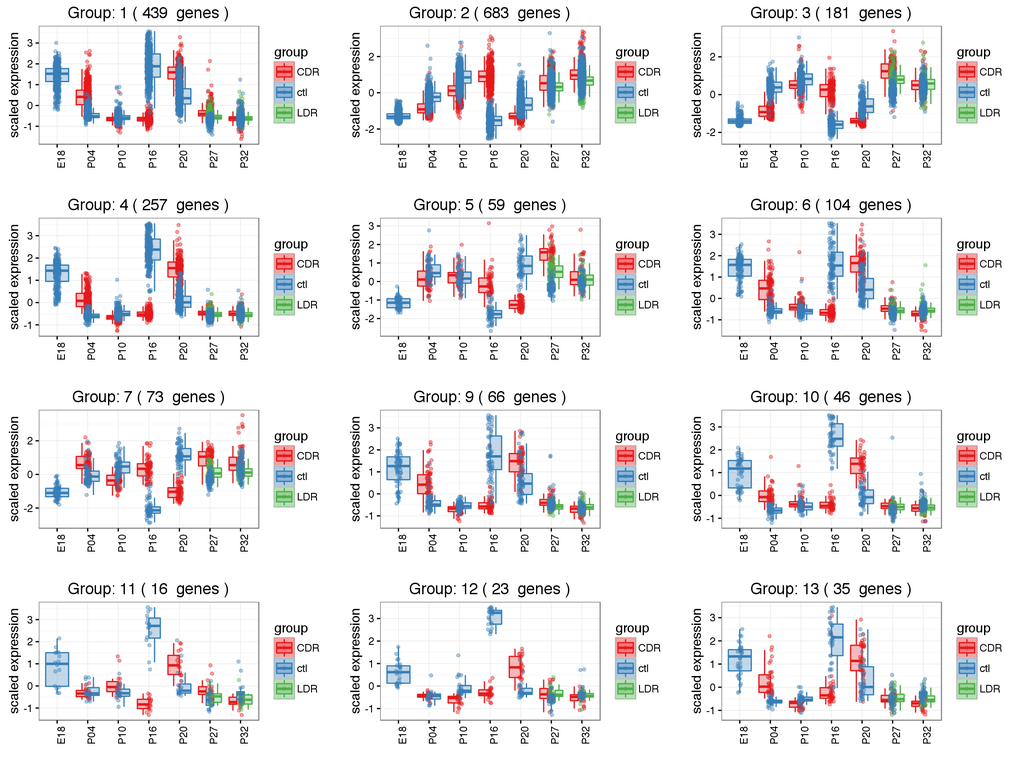

```r
save_file(pattern$df, "clusters_CDRvsCtl.csv", path_results)
```

```r
library(pheatmap)
chosen = list("1"="P16", "2"="P16", "3"="P16", "4"="P16", "6"="P16",
              "7"="P16","9"="P16", "10"="P16", "11"="P16", "12"="P16", "13"="P16")
for (c in names(chosen)){
    cat(paste0("## Cluster ", c, " at time point ", chosen[c]),"\n\n")
    t <- chosen[c]
    g <- as.character(pattern$df$genes[pattern$df$cluster==c])
    s <- colnames(ma)[grepl(t, colnames(ma))]
    cat("\n### heatmap of genes only in that point\n\n")
    pheatmap(log2(ma[g,s]+1), clustering_distance_cols = "correlation", clustering_method = "ward.D2", show_rownames = FALSE, annotation = metadata[,c("type", "time")], main = c)
    cat("\n### PCA of genes only in that point\n\n")
    print(mds(ma[g,s], d = "cor", k =2, condition = metadata[s, "type"]) + ggtitle(c))
    cat("\n### GO standard analysis\n\n")
    cat("\nWorking with ", length(g), " genes\n\n")
    ego <- enrichGO(g, org.Mm.eg.db, keytype = "ENSEMBL", ont = "BP", universe = as.character(comp[[1]]$id))
    ego <- simplify(ego)
    cat("\n\n")
    print(kable(ego@result[,1:7]))
    cat("\n\n")

}
```

## Cluster 1 at time point P16

### heatmap of genes only in that point

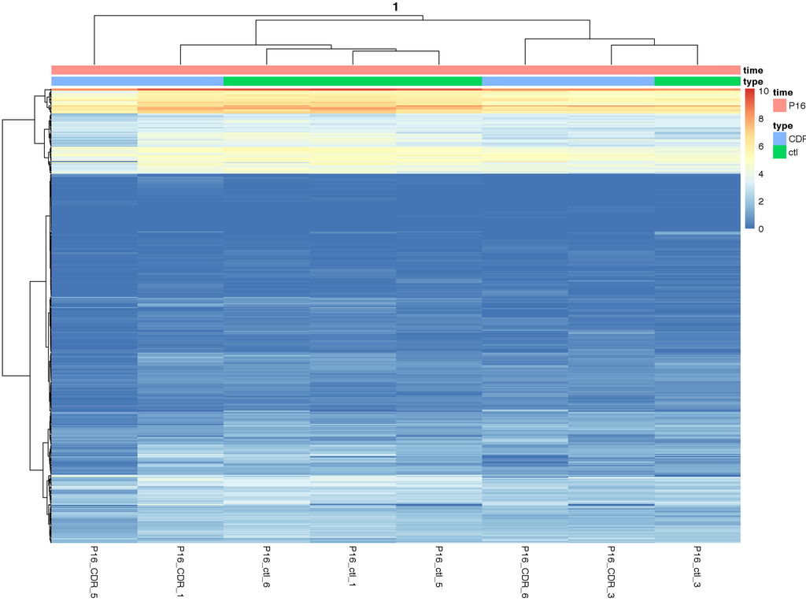

### PCA of genes only in that point

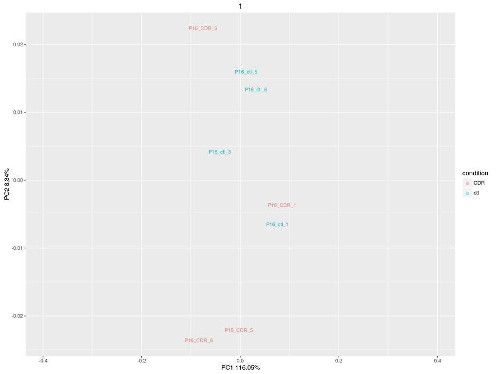

### GO standard analysis

Working with 439 genes

ID Description GeneRatio BgRatio pvalue p.adjust qvalue — ———— ———- ——– ——- ——— ——-

## Cluster 2 at time point P16

### heatmap of genes only in that point

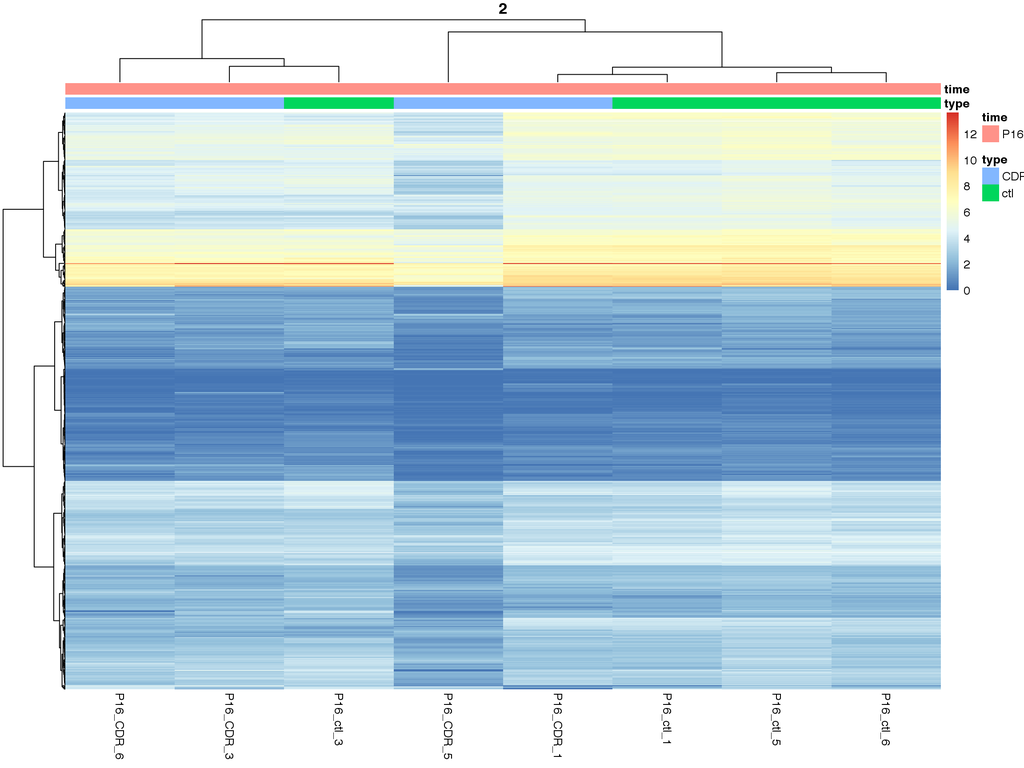

### PCA of genes only in that point

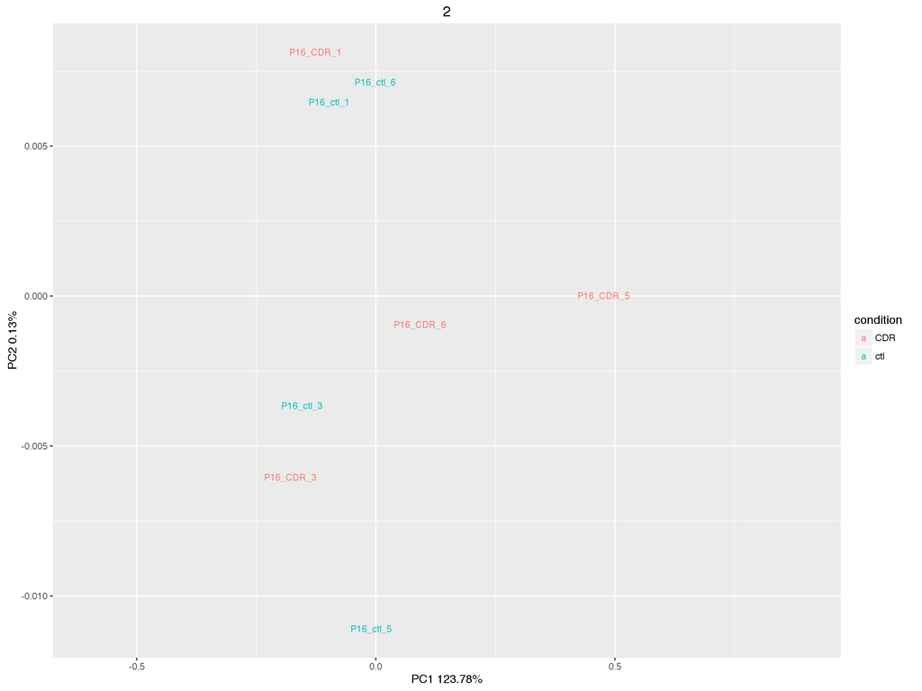

### GO standard analysis

Working with 683 genes

|  | ID | Description | GeneRatio | BgRatio | pvalue | p.adjust | qvalue |
| --- | --- | --- | --- | --- | --- | --- | --- |
| GO:0034765 | GO:0034765 | regulation of ion transmembrane transport | 44/569 | 380/17641 | 0.0000000 | 0.0000000 | 0.0000000 |
| GO:0034762 | GO:0034762 | regulation of transmembrane transport | 45/569 | 396/17641 | 0.0000000 | 0.0000000 | 0.0000000 |
| GO:0071805 | GO:0071805 | potassium ion transmembrane transport | 27/569 | 149/17641 | 0.0000000 | 0.0000000 | 0.0000000 |
| GO:0071804 | GO:0071804 | cellular potassium ion transport | 27/569 | 150/17641 | 0.0000000 | 0.0000000 | 0.0000000 |
| GO:0042391 | GO:0042391 | regulation of membrane potential | 33/569 | 356/17641 | 0.0000001 | 0.0000246 | 0.0000226 |
| GO:0044057 | GO:0044057 | regulation of system process | 35/569 | 448/17641 | 0.0000014 | 0.0003201 | 0.0002939 |
| GO:0003012 | GO:0003012 | muscle system process | 28/569 | 316/17641 | 0.0000014 | 0.0003201 | 0.0002939 |
| GO:0007268 | GO:0007268 | synaptic transmission | 37/569 | 489/17641 | 0.0000015 | 0.0003201 | 0.0002939 |
| GO:0099536 | GO:0099536 | synaptic signaling | 37/569 | 489/17641 | 0.0000015 | 0.0003201 | 0.0002939 |
| GO:0099537 | GO:0099537 | trans-synaptic signaling | 37/569 | 489/17641 | 0.0000015 | 0.0003201 | 0.0002939 |
| GO:0042552 | GO:0042552 | myelination | 16/569 | 120/17641 | 0.0000016 | 0.0003201 | 0.0002939 |
| GO:0006821 | GO:0006821 | chloride transport | 14/569 | 93/17641 | 0.0000016 | 0.0003201 | 0.0002939 |
| GO:0046849 | GO:0046849 | bone remodeling | 12/569 | 79/17641 | 0.0000081 | 0.0010743 | 0.0009866 |
| GO:0044708 | GO:0044708 | single-organism behavior | 32/569 | 447/17641 | 0.0000233 | 0.0023303 | 0.0021402 |
| GO:0031589 | GO:0031589 | cell-substrate adhesion | 22/569 | 279/17641 | 0.0001105 | 0.0084630 | 0.0077726 |
| GO:0007266 | GO:0007266 | Rho protein signal transduction | 14/569 | 141/17641 | 0.0001894 | 0.0128653 | 0.0118158 |
| GO:0035637 | GO:0035637 | multicellular organismal signaling | 12/569 | 109/17641 | 0.0002053 | 0.0136841 | 0.0125678 |
| GO:0090630 | GO:0090630 | activation of GTPase activity | 6/569 | 36/17641 | 0.0009364 | 0.0437817 | 0.0402101 |
| GO:0043410 | GO:0043410 | positive regulation of MAPK cascade | 26/569 | 415/17641 | 0.0010218 | 0.0454151 | 0.0417102 |

## Cluster 3 at time point P16

### heatmap of genes only in that point

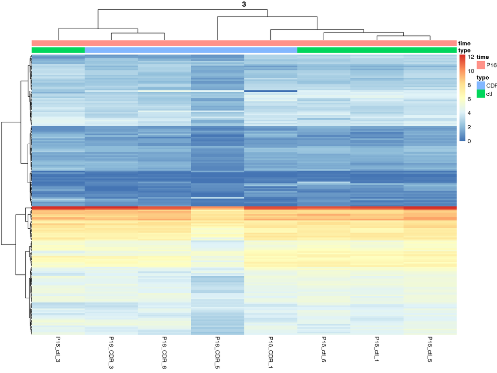

### PCA of genes only in that point

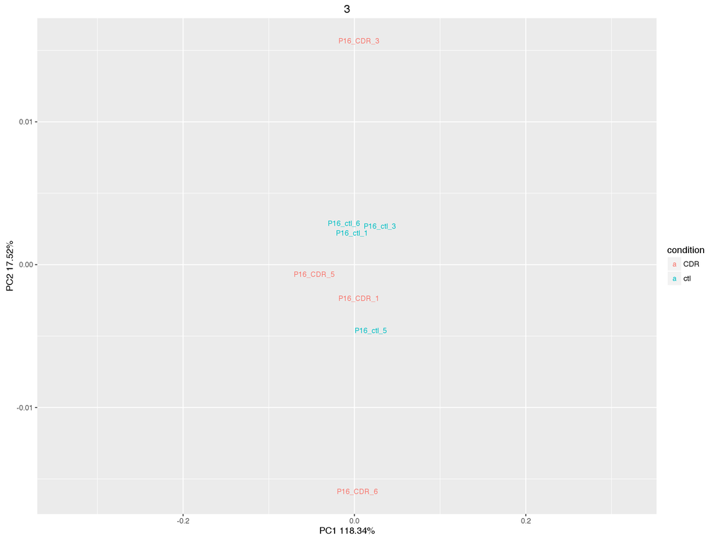

### GO standard analysis

Working with 181 genes

|  | ID | Description | GeneRatio | BgRatio | pvalue | p.adjust | qvalue |
| --- | --- | --- | --- | --- | --- | --- | --- |
| GO:0007272 | GO:0007272 | ensheathment of neurons | 11/156 | 122/17641 | 0.0000000 | 0.0000123 | 0.0000109 |
| GO:0008366 | GO:0008366 | axon ensheathment | 11/156 | 122/17641 | 0.0000000 | 0.0000123 | 0.0000109 |
| GO:0007422 | GO:0007422 | peripheral nervous system development | 7/156 | 61/17641 | 0.0000011 | 0.0004446 | 0.0003931 |
| GO:0043092 | GO:0043092 | L-amino acid import | 4/156 | 17/17641 | 0.0000128 | 0.0035911 | 0.0031754 |
| GO:0021700 | GO:0021700 | developmental maturation | 10/156 | 246/17641 | 0.0000685 | 0.0122381 | 0.0108213 |
| GO:0050432 | GO:0050432 | catecholamine secretion | 5/156 | 51/17641 | 0.0000858 | 0.0132293 | 0.0116977 |
| GO:0030003 | GO:0030003 | cellular cation homeostasis | 14/156 | 477/17641 | 0.0000884 | 0.0132293 | 0.0116977 |
| GO:0042982 | GO:0042982 | amyloid precursor protein metabolic process | 4/156 | 28/17641 | 0.0001021 | 0.0137311 | 0.0121414 |
| GO:0002016 | GO:0002016 | regulation of blood volume by renin-angiotensin | 3/156 | 11/17641 | 0.0001062 | 0.0137311 | 0.0121414 |
| GO:0048659 | GO:0048659 | smooth muscle cell proliferation | 7/156 | 125/17641 | 0.0001232 | 0.0137311 | 0.0121414 |
| GO:0048015 | GO:0048015 | phosphatidylinositol-mediated signaling | 7/156 | 126/17641 | 0.0001295 | 0.0137311 | 0.0121414 |
| GO:0050768 | GO:0050768 | negative regulation of neurogenesis | 10/156 | 267/17641 | 0.0001346 | 0.0137311 | 0.0121414 |
| GO:0070997 | GO:0070997 | neuron death | 11/156 | 324/17641 | 0.0001480 | 0.0140165 | 0.0123938 |
| GO:0044708 | GO:0044708 | single-organism behavior | 13/156 | 447/17641 | 0.0001739 | 0.0156124 | 0.0138050 |
| GO:0042756 | GO:0042756 | drinking behavior | 3/156 | 14/17641 | 0.0002299 | 0.0198387 | 0.0175419 |
| GO:0050678 | GO:0050678 | regulation of epithelial cell proliferation | 10/156 | 290/17641 | 0.0002624 | 0.0206639 | 0.0182716 |
| GO:0009636 | GO:0009636 | response to toxic substance | 7/156 | 148/17641 | 0.0003486 | 0.0227639 | 0.0201285 |
| GO:1903018 | GO:1903018 | regulation of glycoprotein metabolic process | 4/156 | 39/17641 | 0.0003803 | 0.0227639 | 0.0201285 |
| GO:0007268 | GO:0007268 | synaptic transmission | 13/156 | 489/17641 | 0.0004130 | 0.0227639 | 0.0201285 |
| GO:0099536 | GO:0099536 | synaptic signaling | 13/156 | 489/17641 | 0.0004130 | 0.0227639 | 0.0201285 |
| GO:0099537 | GO:0099537 | trans-synaptic signaling | 13/156 | 489/17641 | 0.0004130 | 0.0227639 | 0.0201285 |
| GO:0090184 | GO:0090184 | positive regulation of kidney development | 4/156 | 41/17641 | 0.0004619 | 0.0235559 | 0.0208288 |
| GO:0046688 | GO:0046688 | response to copper ion | 3/156 | 19/17641 | 0.0005924 | 0.0282820 | 0.0250078 |
| GO:0031644 | GO:0031644 | regulation of neurological system process | 5/156 | 79/17641 | 0.0006750 | 0.0298811 | 0.0264217 |
| GO:0019233 | GO:0019233 | sensory perception of pain | 6/156 | 122/17641 | 0.0007553 | 0.0314415 | 0.0278015 |
| GO:0001755 | GO:0001755 | neural crest cell migration | 4/156 | 53/17641 | 0.0012302 | 0.0400095 | 0.0353776 |
| GO:0052547 | GO:0052547 | regulation of peptidase activity | 9/156 | 308/17641 | 0.0017039 | 0.0471417 | 0.0416841 |
| GO:1903524 | GO:1903524 | positive regulation of blood circulation | 5/156 | 99/17641 | 0.0018602 | 0.0496932 | 0.0439402 |

## Cluster 4 at time point P16

### heatmap of genes only in that point

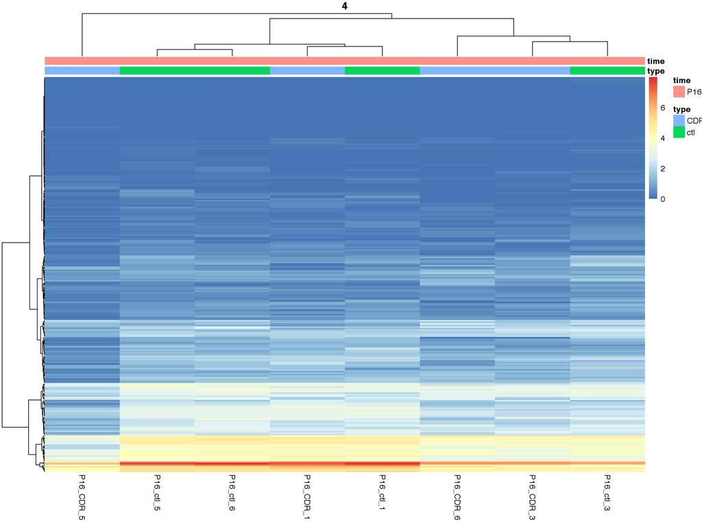

### PCA of genes only in that point

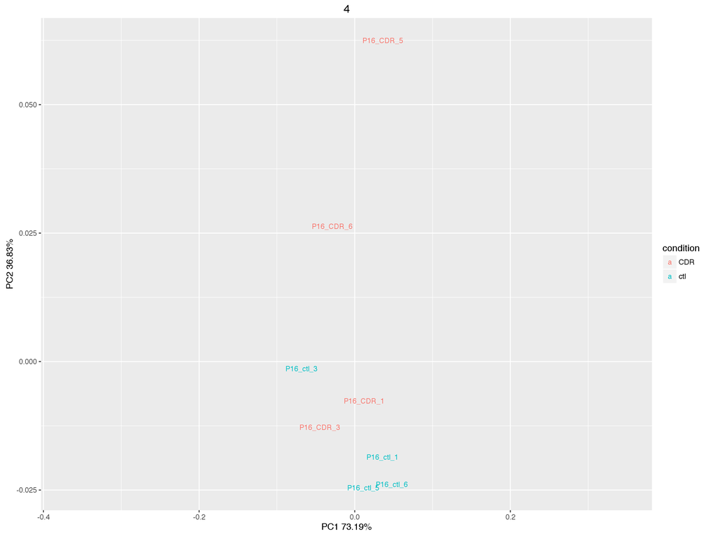

### GO standard analysis

Working with 257 genes

|  | ID | Description | GeneRatio | BgRatio | pvalue | p.adjust | qvalue |
| --- | --- | --- | --- | --- | --- | --- | --- |
| GO:0003341 | GO:0003341 | cilium movement | 6/206 | 48/17641 | 1.92e-05 | 0.0375242 | 0.0361657 |
| GO:0051961 | GO:0051961 | negative regulation of nervous system development | 13/206 | 288/17641 | 3.54e-05 | 0.0375242 | 0.0361657 |